# Homework 4

Halan Badilla Osorio

What I want you to do for this assignment is pick just one of these models and do a little light research.

Spline Regression

1. describe how this model works

The simplest way I can think of explaining this is that this is you using regression but you are splitting your x-var into intervals allowing you to do multiple regressions that best fit in their own separate intervals. These intervals do not need to have a pattern but simply that when splines will connect to the vertical asymptotes, the knots. Now there will be individual regressions per interval allowing you to smooth out the curve fit.

Good link that goes really in depth with them. It is for Python though. https://diogoribeiro7.github.io/data%20science/understanding_splines_what_they_how_they_used_data_analysis/

2. what type of data is this model best used for

Technically this as far as I understand can be used in anything in which you have some sort of regression you’re applying. Specifically though, you’d want to use Splines when you are working with *non-linear trends*, *if your data has any sort of threshold/milestone*, *periodic data* and if *you are missing data and want to interpolate or fill a gap.*

3. what are the advantages and disadvantages

Pros: -Can graph non-linear data better -Flexible -Interpretability (Clear segmentation)

Cons: -You need lots of data, can cause you to overfit -Complex -You need to place knots -Interpretability (Can be a con if it gets too complicated and with the more complicated splines)

4. make a model (it doesn’t have to be complex, just an example)

```r
Sys.setenv(LANG = "en")
library(dplyr)
library(tidyverse)
library(lubridate)
library(ggplot2)
library(splines)
```

```r
setwd("C:/Users/halan/Desktop/FPU/Spring2025/StatisticalLearning/")
banana <- read_csv("banana_quality.csv")
```

```r
# Factoring Quality
banana$Quality <- factor(banana$Quality)

unique(banana$Quality)
```

```
[1] Good Bad
Levels: Bad Good
```

```r
cleanBanana <- na.omit(banana)
# Abritrary weighted mean that I will use
weights <- c(.2, .05, .1, .1, .05, .4, .1)

bananaAvg <- cleanBanana %>%
  mutate(randomQuantifier = (Size*weights[1] + Weight*weights[2] + Sweetness*weights[3] + Softness*weights[4] + HarvestTime*weights[5] + Ripeness*weights[6] + Acidity*weights[7]))

# Linear Model using all points
bananaModel <- glm(Quality ~ bs(randomQuantifier, df = 6), data = bananaAvg, family = "binomial")

# Getting the knot info for visualization

knots <- attr(bs(cleanBanana$randomQuantifier, df = 6), "knots")

# Linear Model using all points
bananaModel2 <- glm(Quality ~ bs(randomQuantifier, df = 9), data = bananaAvg, family = "binomial")

# Getting the knot info for visualization

knots2 <- attr(bs(cleanBanana$randomQuantifier, df = 9), "knots")


summary(bananaModel)
```

```
Call:
glm(formula = Quality ~ bs(randomQuantifier, df = 6), family = "binomial",
    data = bananaAvg)

Coefficients:
                              Estimate Std. Error z value Pr(>|z|)
(Intercept)                     -4.735      5.020  -0.943    0.346
bs(randomQuantifier, df = 6)1   -1.204      5.901  -0.204    0.838
bs(randomQuantifier, df = 6)2    1.223      4.884   0.250    0.802
bs(randomQuantifier, df = 6)3    5.091      5.051   1.008    0.314
bs(randomQuantifier, df = 6)4    7.004      4.980   1.406    0.160
bs(randomQuantifier, df = 6)5    7.350      5.110   1.438    0.150
bs(randomQuantifier, df = 6)6    7.506      5.057   1.484    0.138

(Dispersion parameter for binomial family taken to be 1)

    Null deviance: 11090.3  on 7999  degrees of freedom
Residual deviance:  7287.4  on 7993  degrees of freedom
AIC: 7301.4

Number of Fisher Scoring iterations: 7
```

```r
bananaAvg$predProb <- predict(bananaModel, type = "response")
bananaAvg$predProb2 <- predict(bananaModel2, type = "response")
```

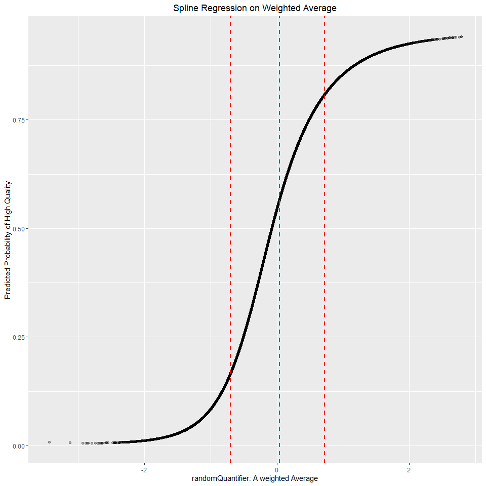

```r
ggplot(bananaAvg, aes(x = randomQuantifier, y = predProb)) +
  geom_point(alpha = 0.3) +
  #geom_smooth(method = "loess", se = FALSE, color = "lightblue") +
  geom_vline(xintercept = knots, linetype = "dashed", color = "red", size = 1) +
  labs(title = "Spline Regression on Weighted Average",
       y = "Predicted Probability of High Quality", x = "randomQuantifier: A weighted Average")+
  theme(plot.title = element_text(hjust = 0.5))
```

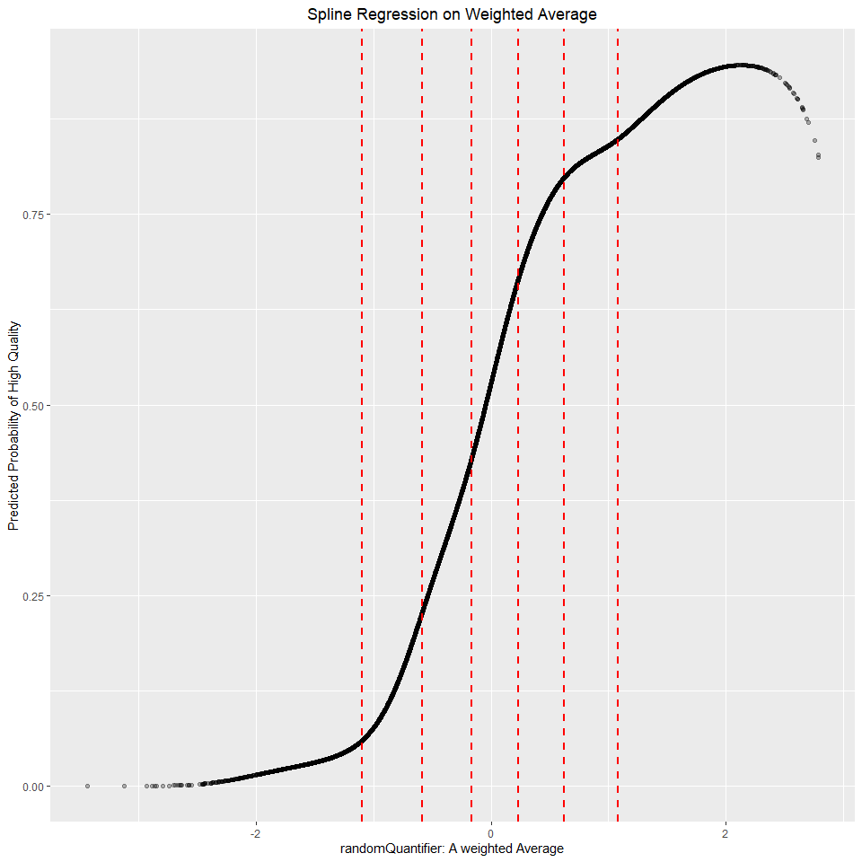

```r
ggplot(bananaAvg, aes(x = randomQuantifier, y = predProb2)) +
  geom_point(alpha = 0.3) +
  #geom_smooth(method = "loess", se = FALSE, color = "lightblue") +
  geom_vline(xintercept = knots2, linetype = "dashed", color = "red", size = 1) +
  labs(title = "Spline Regression on Weighted Average",
       y = "Predicted Probability of High Quality", x = "randomQuantifier: A weighted Average")+
  theme(plot.title = element_text(hjust = 0.5))
```

6. cite a research paper which uses this model type in its work

https://kk.unmeka.ac.id/scholarhub/Spline%20regression%20in%20clinical%20research.pdf

This research paper uses spline regression in a clinical setting to display the continuous relationship between SA levels and mortality risk.

The main reason of this paper was for the author to introduce the usage of spline regression in their hospital showcasing better results that are also potentially less misleading as it showcases the data much more accurately.

The original/traditional way was using categorical analysis whereas spline regression offered a better more smoothed out while still using the same three categories. The new approach allowed it to display variation within the categories initially used that would have been missed when compared to the traditional means.

The limitation for this is simply the knowledge of how to apply it but also slight computational resource increase. Knowing where to and how many knots to place is another issue. The models shape and accuracy can highly be dependent on that. If the knots are not chosen correctly it can end up being even misleading. Of course this can be minimized by using other techniques to smooth it out or find the optimal amount of knots. And the biggest limitation is simply when used on linear data, there is no point to it if your data is linear.